# Reproducible Research: Peer Assessment 1

## Loading and preprocessing the data

```r
Activity<-read.csv("activity.csv")
head(Activity)
```

```
##   steps       date interval
## 1    NA 2012-10-01        0
## 2    NA 2012-10-01        5
## 3    NA 2012-10-01       10
## 4    NA 2012-10-01       15
## 5    NA 2012-10-01       20
## 6    NA 2012-10-01       25
```

## What is mean total number of steps taken per day?

###Calculate total steps taken per day.

```r
TotalDailySteps<-aggregate(steps~date, Activity, sum)
```

###Place data into Histogram

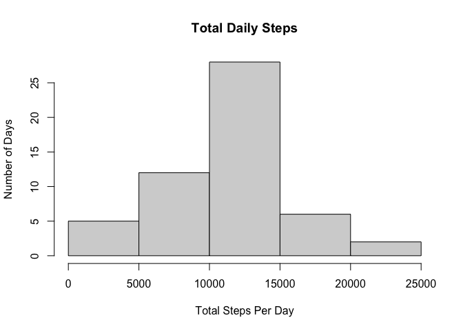

```r
hist(TotalDailySteps$steps, xlab="Total Steps Per Day", ylab="Number of Days", main="Total Daily Steps")
```

###Calculate and report the mean and median of the total number of steps taken per day. ###Calculate the mean

```r
meanDailySteps<-mean(TotalDailySteps$steps)
meanDailySteps
```

```
## [1] 10766.19
```

###Calculate the median

```r
medianDailySteps<-median(TotalDailySteps$steps)
medianDailySteps
```

```
## [1] 10765
```

## What is the average daily activity pattern?

###Make a time series plot (i.e. type = “l”) of the 5-minute interval (x-axis) and the average number of steps taken, averaged across all days (y-axis) ###Take average number of steps.

```r
AverageNumberSteps<-aggregate(steps~interval, Activity, mean)
```

###Make time series plot.

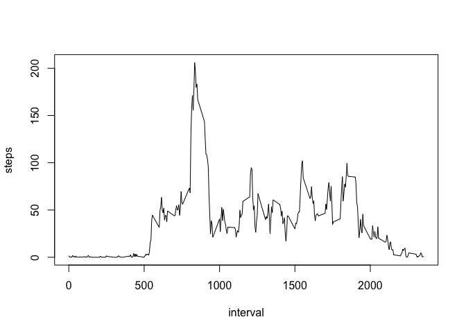

```r
with(AverageNumberSteps, plot(interval, steps, type = "l"))
```

###Which 5-minute interval, on average across all the days in the dataset, contains the maximum number of steps?

```r
AverageNumberSteps[which.max(AverageNumberSteps[,2]),1]
```

```
## [1] 835
```

## Imputing missing values

###Calculate and report the total number of missing values in the dataset (i.e. the total number of rows with NAs)

```r
MissingValues<-is.na(Activity[,1])
```

```r
summary(MissingValues)
```

```
##    Mode   FALSE    TRUE
## logical   15264    2304
```

###2304 missing values

###Devise a strategy for filling in all of the missing values in the dataset.

```r
AddedMissingValues <- AverageNumberSteps$Mean[match(Activity$interval, AverageNumberSteps$Interval)]
```

###Create a new dataset that is equal to the original dataset but with the missing data filled in.

```r
ActivityDataFilled<- transform(Activity,
                          steps = ifelse(is.na(Activity$steps),
                yes = MissingValues, no = Activity$steps))
```

###new dataset with values added

```r
TotalFilledData <- aggregate(steps ~ date, ActivityDataFilled, sum)
```

```r
names(TotalFilledData) <- c("date", "dailySteps")
```

```r
sum(is.na(TotalFilledData$dailySteps))
```

```
## [1] 0
```

###checks out.

###build data frame

```r
DFTotalFilledData <- data.frame(TotalFilledData)
```

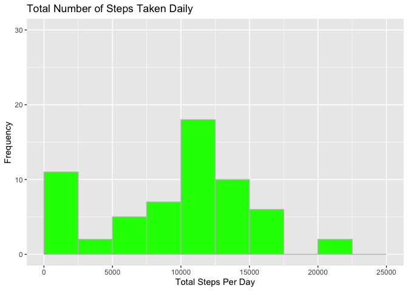

```r
StepsDataTotal <- ggplot(DFTotalFilledData, aes(x = dailySteps)) +
  geom_histogram(breaks = seq(0, 25000, by = 2500), fill = "green", col = "grey") +
  ylim(0, 30) +
  xlab("Total Steps Per Day") +
  ylab("Frequency") +
  ggtitle("Total Number of Steps Taken Daily")


print(StepsDataTotal)
```

###find mean

```r
mean(TotalFilledData$dailySteps)
```

```
## [1] 9392
```

###find median

```r
median(TotalFilledData$dailySteps)
```

```
## [1] 10395
```

## Are there differences in activity patterns between weekdays and weekends?

###make sure date is in appropriate format

```r
Activity$date <- as.Date(strptime(Activity$date, format="%Y-%m-%d"))
```

```r
Activity$dayType <- sapply(Activity$date, function(x) {
  if(weekdays(x) == "Saturday" | weekdays(x) == "Sunday")
  {y <- "Weekend"}
  else {y <- "Weekday"}
  y
})
```

```r
ActivityDay <-  aggregate(steps ~ interval + dayType, Activity, mean, na.rm = TRUE)
```

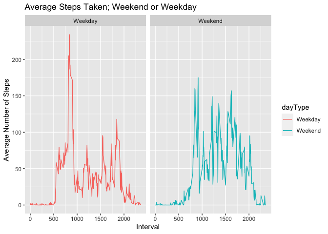

```r
PerDay <-  ggplot(ActivityDay, aes(x = interval , y = steps, color = dayType)) +
  geom_line() + ggtitle("Average Steps Taken; Weekend or Weekday") +
  xlab("Interval") +
  ylab("Average Number of Steps") +
  facet_wrap(~dayType, ncol = 2, nrow=1)



print(PerDay)
```